# Effects of Employment Rate on the US Dollar

**Spring 2024 Data Science Project**

**Author:** Benard Wangombe Kihiuria

**Introduction:** This study was conducted to find out whether or not we can use fundamental analysis (formal analysis technique that takes into consideration variables such as news, interest rates, etc.) in the form of analyzing unemployment rates, to determine whether or not to buy a currency. The goal is to potentially find a correlation between US unemployment rate and current conversion rates and be able to predict what the price should be based off of the unemployment report. Confirmation that there is a correlation between unemployment and the conversion rate would then allow someone to be able to predict what the conversion rate should theoretically be, and decide to buy or sell their currency. Answering these questions would be important as it would allow traders to have more information at their fingertips that they could use to make better and more informed decisions.

## Part 0: Background Knowledge

### What is Forex?

**Definition** **:** Forex (FX) refers to the global electronic marketplace for trading international currencies and currency derivatives. It has no central physical location, yet the forex market is the largest, most liquid market in the world by trading volume, with trillions of dollars changing hands every day. Most of the trading is done through banks, brokers, and financial institutions.

This is the same market that the US Dollar is traded on with institutions buying and selling the currency that they believe is going to increase in price.

### How Pairs Are Organized

For currency pairs it is necessary to buy a currency in reference to another currency. There is a standardized way that they are organized to know which currency you are expecting to rise or fall. For example let us reference the currency pair USD/JPY. In these cases the first currency listed (USD) is considered the base currency and the second currency (JPY) is considered the quote currency

### What do Base and Quote Currencies Even Mean?

What you are analyzing when you look at a price in reference to base and quote currencies is essentially what the base currency is worth in context to the quote currency. In other words how much of the quote currency will you receive for one unit of the base currency. With in the case of USD/JPY which currently has a value of 151.36. This means that for 1 US Dollar you will receive 151.36 Japanese Yen.

### How to Determine the Weakness and Strength of a Currency?

With this in hand we are able to understand that when a base currency has a strong economy then it will be worth more in the quote currency, and the opposite being true in when the economy of the base currency is weak it will be worth less in the quote currency.

### How to Make Profit?

Using this forex traders are able to make profits on the rise and fall of a currency. Where if you believe that the currency is going to fall in reference to the quote currency you buy alot of the quote currency and when it reaches your profit point you buy the base currency back with the quote currency you bought initially. And vice versa if you believe it is going to rise you buy alot of the base currency and when it is worth more in the quote currency then you exchange it for a profit.

### Additional Reading

[Introduction to Forex](https://www.investopedia.com/terms/f/forex.asp)  
[Introduction to Fundamental Analysis](https://www.investopedia.com/terms/f/fundamentalanalysis.asp)  
[Daily Forex News Updates](https://www.forexfactory.com/news)  
[Scientific Paper About the Validity of Fundamental Analysis](https://www.sciencedirect.com/science/article/pii/S2212567115013441)

## Part 1: Import Essential Libraries & Citations

```python
import pandas as pd
import numpy as np
import scipy
import re
import matplotlib.pyplot as plt
import matplotlib.dates as mdates
import datetime as dt
from sklearn.model_selection import train_test_split
from sklearn.linear_model import LinearRegression
from sklearn.metrics import mean_squared_error, r2_score
from sklearn.preprocessing import PolynomialFeatures
from sklearn.pipeline import make_pipeline
```

### Citations

Finance, Yahoo. “AUD/USD Historical Data.” Accessed 21 Feb. 2024. https://finance.yahoo.com/quote/AUDUSD.

Finance, Yahoo. “EUR/USD Historical Data.” Accessed 21 Feb. 2024. https://finance.yahoo.com/quote/EURUSD.

Finance, Yahoo. “GPB/USD Historical Data.” Accessed 21 Feb. 2024. https://finance.yahoo.com/quote/GPBUSD.

Finance, Yahoo. “USD/JPY Historical Data.” Accessed 21 Feb. 2024. https://finance.yahoo.com/quote/USDJPY.

Finance, Yahoo. “USD/CHF Historical Data.” Accessed 21 Feb. 2024. https://finance.yahoo.com/quote/USDCHF.

U.S. Bureau of Labor Statistics, Unemployment Rate, retrieved from FRED, Federal Reserve Bank of St. Louis. Accessed March 25, 2024.  
https://fred.stlouisfed.org/series/UNRATE

## Part 2: Import Datasets

**TASK 2.1:** First we want to import all the necessary forex pairs

```python
audusd_df = pd.read_csv('forexPairs/audusd.csv')
eurusd_df = pd.read_csv('forexPairs/eurusd.csv')
gbpusd_df = pd.read_csv('forexPairs/gbpusd.csv')
usdchf_df = pd.read_csv('forexPairs/usdchf.csv')
usdjpy_df = pd.read_csv('forexPairs/usdjpy.csv')
```

**TASK 2.2:** Next we want to import datasets about the relevant unemployment news.

```python
unemployment_df = pd.read_csv('news/unemployment.csv')
```

## Part 3: Data Cleaning

**TASK 3.1:** Fixing Forex Pairs

```python
audusd_df
```

|  | Date | Open | High | Low | Close | Adj Close | Volume |
| --- | --- | --- | --- | --- | --- | --- | --- |
| 0 | 2014-02-21 | 0.901120 | 0.901632 | 0.895255 | 0.900982 | 0.900982 | 0.0 |
| 1 | 2014-02-24 | 0.897908 | 0.901957 | 0.893975 | 0.897747 | 0.897747 | 0.0 |
| 2 | 2014-02-25 | 0.903677 | 0.904323 | 0.900739 | 0.903751 | 0.903751 | 0.0 |
| 3 | 2014-02-26 | 0.901145 | 0.902690 | 0.895977 | 0.900982 | 0.900982 | 0.0 |
| 4 | 2014-02-27 | 0.896379 | 0.896861 | 0.890710 | 0.896379 | 0.896379 | 0.0 |
| ... | ... | ... | ... | ... | ... | ... | ... |
| 2604 | 2024-02-15 | 0.649880 | 0.652910 | 0.647849 | 0.649880 | 0.649880 | 0.0 |
| 2605 | 2024-02-16 | 0.652550 | 0.653518 | 0.649860 | 0.652550 | 0.652550 | 0.0 |
| 2606 | 2024-02-19 | 0.653740 | 0.655100 | 0.653398 | 0.653791 | 0.653791 | 0.0 |
| 2607 | 2024-02-20 | 0.653078 | 0.657810 | 0.652240 | 0.653078 | 0.653078 | 0.0 |
| 2608 | 2024-02-21 | 0.653424 | 0.657419 | 0.654437 | 0.654510 | 0.654510 | 0.0 |

2609 rows × 7 columns

Firstly for the forex pairs we do not really care about their specifics as seen above such as the High, Low, Adj Close, and Volume as the Open and Close is all the information we need so we are going to remove them.

The dates are also in the correct format so we can leave them as they are

```python
audusd_df.drop(['High', 'Open', 'Low','Adj Close', 'Volume'], axis=1, inplace=True)
eurusd_df.drop(['High', 'Open', 'Low','Adj Close', 'Volume'], axis=1, inplace=True)
gbpusd_df.drop(['High', 'Open', 'Low','Adj Close', 'Volume'], axis=1, inplace=True)
usdchf_df.drop(['High', 'Open', 'Low','Adj Close', 'Volume'], axis=1, inplace=True)
usdjpy_df.drop(['High', 'Open', 'Low','Adj Close', 'Volume'], axis=1, inplace=True)
```

```python
audusd_df
```

|  | Date | Close |
| --- | --- | --- |
| 0 | 2014-02-21 | 0.900982 |
| 1 | 2014-02-24 | 0.897747 |
| 2 | 2014-02-25 | 0.903751 |
| 3 | 2014-02-26 | 0.900982 |
| 4 | 2014-02-27 | 0.896379 |
| ... | ... | ... |
| 2604 | 2024-02-15 | 0.649880 |
| 2605 | 2024-02-16 | 0.652550 |
| 2606 | 2024-02-19 | 0.653791 |
| 2607 | 2024-02-20 | 0.653078 |
| 2608 | 2024-02-21 | 0.654510 |

2609 rows × 2 columns

**TASK 3.2:** Fixing Unemployment Data

```python
unemployment_df
```

|  | DATE | UNRATE |
| --- | --- | --- |
| 0 | 2014-02-01 | 6.7 |
| 1 | 2014-03-01 | 6.7 |
| 2 | 2014-04-01 | 6.2 |
| 3 | 2014-05-01 | 6.3 |
| 4 | 2014-06-01 | 6.1 |
| ... | ... | ... |
| 116 | 2023-10-01 | 3.8 |
| 117 | 2023-11-01 | 3.7 |
| 118 | 2023-12-01 | 3.7 |
| 119 | 2024-01-01 | 3.7 |
| 120 | 2024-02-01 | 3.9 |

121 rows × 2 columns

For the unemployment data the only issue seems to be the naming which we shall fix

```python
unemployment_df.rename(columns = {'DATE':'Date', 'UNRATE':'Unemployment Rate'}, inplace = True)
unemployment_df
```

|  | Date | Unemployment Rate |
| --- | --- | --- |
| 0 | 2014-02-01 | 6.7 |
| 1 | 2014-03-01 | 6.7 |
| 2 | 2014-04-01 | 6.2 |
| 3 | 2014-05-01 | 6.3 |
| 4 | 2014-06-01 | 6.1 |
| ... | ... | ... |
| 116 | 2023-10-01 | 3.8 |
| 117 | 2023-11-01 | 3.7 |
| 118 | 2023-12-01 | 3.7 |
| 119 | 2024-01-01 | 3.7 |
| 120 | 2024-02-01 | 3.9 |

121 rows × 2 columns

**TASK 3.3:** Convert all date columns to datetime

```python
audusd_df['Date'] = pd.to_datetime(audusd_df['Date'])
eurusd_df['Date'] = pd.to_datetime(eurusd_df['Date'])
gbpusd_df['Date'] = pd.to_datetime(gbpusd_df['Date'])
usdchf_df['Date'] = pd.to_datetime(usdchf_df['Date'])
usdjpy_df['Date'] = pd.to_datetime(usdjpy_df['Date'])

unemployment_df['Date'] = pd.to_datetime(unemployment_df['Date'])
```

## Part 4: Observations

**Task 4.1** **:** Outliers

As one would expect in the context of fundamental analysis of forex pairs and currencies there are outliers that show themselves in cases of financial depression and one case of that in recent years was the COVID pandemic. We saw things such as interest rates rise tremendously, gas prices, and last but not least unemployment rates themselves often as a result of economic shock which has influence in these areas.

This increase in unemployment rates can be seen by the graph below.

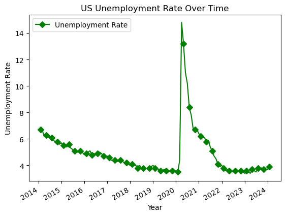

```python
# Make a simple plot of the US Unemployment Rate over time

plt.plot(unemployment_df['Date'], unemployment_df['Unemployment Rate'], '-gD', markevery=3, label="Unemployment Rate")
plt.xlabel('Year')
plt.ylabel('Unemployment Rate')
plt.title('US Unemployment Rate Over Time')
plt.gcf().autofmt_xdate()
plt.legend(loc="upper left")
plt.show()
```

**Task 4.2** **:** More Information About The Distribution

Before we continue we also want to get a good understanding more information about the unemployment rate and the data it comes with. To visualize this I have decided to use a box and whisker plot which allows us to get a general idea of the min, max, and the percentile range we should expect which will come in handy in analyzing how unemployment rate affects the currency pairs themselves.

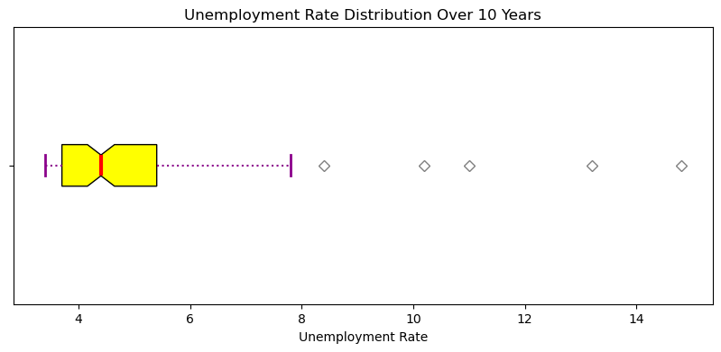

```python
# Create a box and whisker plot outlining the distribution

fig = plt.figure(figsize =(10, 4))
ax = fig.add_subplot(111)

bp = ax.boxplot(unemployment_df["Unemployment Rate"], patch_artist = True,
                notch ='True', vert = 0)

# Custom color settings
colors = ['#FFFF00']

for patch, color in zip(bp['boxes'], colors):
    patch.set_facecolor(color)

for whisker in bp['whiskers']:
    whisker.set(color ='#8B008B',
                linewidth = 1.5,
                linestyle =":")

for cap in bp['caps']:
    cap.set(color ='#8B008B',
            linewidth = 2)

for median in bp['medians']:
    median.set(color ='red',
               linewidth = 3)

for flier in bp['fliers']:
    flier.set(marker ='D',
              color ='#e7298a',
              alpha = 0.5)

ax.set_yticklabels([''])

plt.title("Unemployment Rate Distribution Over 10 Years")

ax.get_xaxis().tick_bottom()
ax.get_yaxis().tick_left()
plt.xlabel('Unemployment Rate')

plt.show()
```

To get a concrete idea of the unemployment rate we can also use the describe function to understand the data better

```python
unemployment_df.describe()
```

|  | Unemployment Rate |
| --- | --- |
| count | 121.000000 |
| mean | 4.861157 |
| std | 1.764623 |
| min | 3.400000 |
| 25% | 3.700000 |
| 50% | 4.400000 |
| 75% | 5.400000 |
| max | 14.800000 |

After using describe we are also able to understand the standard deviation of the dataframe which was surprising as it suggests that the unemployment rate is oftentimes relatively high above 5 percent. Using this we are able to identify potential profit opportunities.

**Task 4.3** **:** Looking at Forex Pairs and Correlations

As we are working with forex pairs and unemployment rate I also wondered whether or not there was a correlation between the pairs themselves as they are all based off the US Dollar. In essence testing whether or not for example if one pair rises does the other as well? To visualize how they related to each other I decided to plot out the individual closing prices of my currencies over a 10 year gap on the same graph to estimate how much they differed from one another and test their correlation score using a correlation matrix.

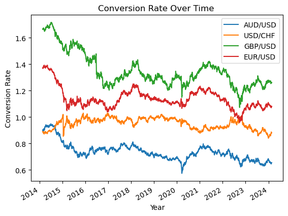

```python
# Plot every individual closing price for each pair in regards to the current date
plt.plot(audusd_df['Date'], audusd_df['Close'], label = "AUD/USD")
plt.plot(usdchf_df['Date'], usdchf_df['Close'], label = "USD/CHF")
plt.plot(gbpusd_df['Date'], gbpusd_df['Close'], label = "GBP/USD")
plt.plot(eurusd_df['Date'], eurusd_df['Close'], label = "EUR/USD")

# I decided to ignore USD/JPY for the moment as because it trades for 150 currently which makes the graph unreadable

# Simple plot
plt.xlabel('Year')
plt.ylabel('Conversion Rate')
plt.title('Conversion Rate Over Time ')
plt.gcf().autofmt_xdate()
plt.legend(loc="upper right")
plt.show()
```

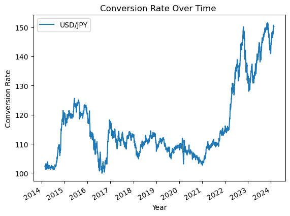

```python
#USD/JPY by itself to show the difference
plt.plot(usdjpy_df['Date'], usdjpy_df['Close'], label = "USD/JPY")

plt.xlabel('Year')
plt.ylabel('Conversion Rate')
plt.title('Conversion Rate Over Time ')
plt.gcf().autofmt_xdate()
plt.legend(loc="upper left")
plt.show()
```

Let's create a dataframe with all the closing prices for all forex pairs. We also know that they are ordered correctly with the same length and dates in place so we can continue accordingly.

```python
# Create a dataframe with simply closing prices
df = pd.DataFrame([])
df['Date'] = gbpusd_df['Date']
df['GBP/USD'] = gbpusd_df['Close']
df['EUR/USD'] = eurusd_df['Close']
df['AUD/USD'] = audusd_df['Close']
df['USD/JPY'] = usdjpy_df['Close']
df['USD/CHF'] = usdchf_df['Close']

corr_matrix = df.corr(numeric_only=True)
corr_matrix
```

|  | GBP/USD | EUR/USD | AUD/USD | USD/JPY | USD/CHF |
| --- | --- | --- | --- | --- | --- |
| GBP/USD | 1.000000 | 0.725762 | 0.795945 | -0.359831 | -0.219661 |
| EUR/USD | 0.725762 | 1.000000 | 0.828202 | -0.600479 | -0.368048 |
| AUD/USD | 0.795945 | 0.828202 | 1.000000 | -0.530205 | -0.152599 |
| USD/JPY | -0.359831 | -0.600479 | -0.530205 | 1.000000 | -0.231432 |
| USD/CHF | -0.219661 | -0.368048 | -0.152599 | -0.231432 | 1.000000 |

It should also be noted that we have to take into account that for JPY and CHF the USD is actually the base currency in those cases instead of being the quote currency as it is in GBP, EUR, and AUD. To fix this I will negate the negative correlations that arise which are assuming USD as the quote currency. However we have to keep in mind to not change the JPY to CHF correlations as those pairs are in the correct correlation with one another.

```python
chfusd_val = corr_matrix.at['USD/JPY','USD/CHF']

corr_matrix['GBP/USD'] = corr_matrix['GBP/USD'].apply(lambda x: -x if x < 0.0 else x)
corr_matrix['EUR/USD'] = corr_matrix['EUR/USD'].apply(lambda x: -x if x < 0.0 else x)
corr_matrix['AUD/USD'] = corr_matrix['AUD/USD'].apply(lambda x: -x if x < 0.0 else x)
corr_matrix['USD/JPY'] = corr_matrix['USD/JPY'].apply(lambda x: -x if x < 0.0 else x)
corr_matrix['USD/CHF'] = corr_matrix['USD/CHF'].apply(lambda x: -x if x < 0.0 else x)

#Re negating the columns regarding JPY and CHF
corr_matrix.at['USD/JPY','USD/CHF'] = chfusd_val
corr_matrix.at['USD/CHF','USD/JPY'] = chfusd_val
corr_matrix
```

|  | GBP/USD | EUR/USD | AUD/USD | USD/JPY | USD/CHF |
| --- | --- | --- | --- | --- | --- |
| GBP/USD | 1.000000 | 0.725762 | 0.795945 | 0.359831 | 0.219661 |
| EUR/USD | 0.725762 | 1.000000 | 0.828202 | 0.600479 | 0.368048 |
| AUD/USD | 0.795945 | 0.828202 | 1.000000 | 0.530205 | 0.152599 |
| USD/JPY | 0.359831 | 0.600479 | 0.530205 | 1.000000 | -0.231432 |
| USD/CHF | 0.219661 | 0.368048 | 0.152599 | -0.231432 | 1.000000 |

Through this we actually get a lot of insight on how different currencies may interact with each other. For example with GBP and the EUR they seem to be correlated with each other relatively strongly because they have relatively similar industries that they focus on. We also see that CHF tends to not correlate strongly with any of the other currencies and even has a negative correlation with JPY. However something that was interesting was that EUR/USD had the strongest correlation with the whole group and on average correlated with the most currencies.

**Task 4.4** **:** Hypothesis Test

Null Hypothesis H0: There is no relationship between unemployment rate and currency pairs  
Alternative Hypothesis H1: There is a relationship between unemployment rate and currency pairs  
Significance Rate = 0.05

First to check this we want to use a chi squared test and to do that we need to categorically regard the data as whether or not it is greater than the mean of each respective pair so we are going to create a new column adressing that fact for every single pair and store it in a temp_df variable.

We also want to merge our temporary dataframe with the respective unemployment rate

```python
# Instantiate pairs for simpler iteration
pairs = ["GBP/USD", 'EUR/USD', 'AUD/USD' , 'USD/JPY', 'USD/CHF']
```

```python
# Function that will be run on each column regarding whether or not the current currency rate is higher than the mean given its unemployment rate
def is_greater_than_mean(x, mean):
    if x >= mean:
        return 'No'
    else :
        return 'Yes'

# Create a temp_df we can use and modify freely
temp_df = df
temp_df = temp_df[temp_df["Date"].dt.day == 1]
temp_df = pd.merge(temp_df, unemployment_df)

# Creating the new columns
for i in pairs:
    try:
        temp_df[f"Greater Than Mean: {i}"] = temp_df[i].apply(lambda x: is_greater_than_mean(x, df[i].describe()['mean']))
    except Exception:
        continue
```

```python
temp_df
```

|  | Date | GBP/USD | EUR/USD | AUD/USD | USD/JPY | USD/CHF | Unemployment Rate | Greater Than Mean: GBP/USD | Greater Than Mean: EUR/USD | Greater Than Mean: AUD/USD | Greater Than Mean: USD/JPY | Greater Than Mean: USD/CHF |
| --- | --- | --- | --- | --- | --- | --- | --- | --- | --- | --- | --- | --- |
| 0 | 2014-04-01 | 1.666639 | 1.377505 | 0.926870 | 103.213997 | 0.884200 | 6.2 | No | No | No | Yes | Yes |
| 1 | 2014-05-01 | 1.687650 | 1.386924 | 0.928333 | 102.220001 | 0.880000 | 6.3 | No | No | No | Yes | Yes |
| 2 | 2014-07-01 | 1.710981 | 1.369357 | 0.942951 | 101.290001 | 0.886730 | 6.2 | No | No | No | Yes | Yes |
| 3 | 2014-08-01 | 1.689161 | 1.338993 | 0.930233 | 102.773003 | 0.908500 | 6.1 | No | No | No | Yes | Yes |
| 4 | 2014-09-01 | 1.659255 | 1.312784 | 0.933010 | 104.167999 | 0.918910 | 5.9 | No | No | No | Yes | Yes |
| ... | ... | ... | ... | ... | ... | ... | ... | ... | ... | ... | ... | ... |
| 82 | 2023-09-01 | 1.267283 | 1.084410 | 0.648841 | 145.473007 | 0.883200 | 3.8 | Yes | Yes | Yes | No | Yes |
| 83 | 2023-11-01 | 1.215214 | 1.057910 | 0.633995 | 151.294006 | 0.909800 | 3.7 | Yes | Yes | Yes | No | Yes |
| 84 | 2023-12-01 | 1.263169 | 1.089206 | 0.660680 | 147.998993 | 0.874660 | 3.7 | Yes | Yes | Yes | No | Yes |
| 85 | 2024-01-01 | 1.273000 | 1.105583 | 0.682049 | 140.951996 | 0.840759 | 3.7 | Yes | Yes | Yes | No | Yes |
| 86 | 2024-02-01 | 1.267845 | 1.080392 | 0.656151 | 146.996002 | 0.862340 | 3.9 | Yes | Yes | Yes | No | Yes |

87 rows × 12 columns

```
P-Value for GBP/USD = 0.0020695437403777115
P-Value for EUR/USD = 0.00044713207193868124
P-Value for AUD/USD = 0.0022100141577719983
P-Value for USD/JPY = 0.06859729568406199
P-Value for USD/CHF = 0.12016970806401533
```

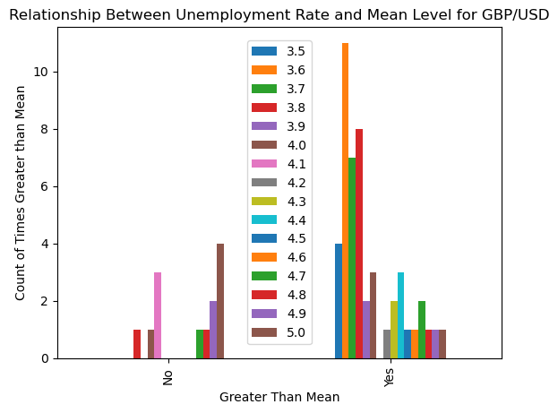

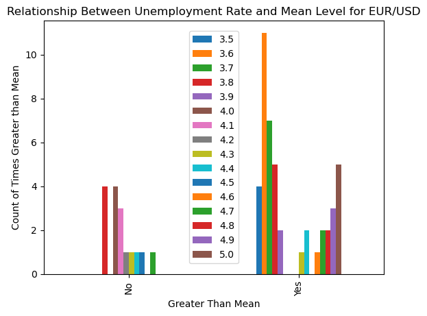

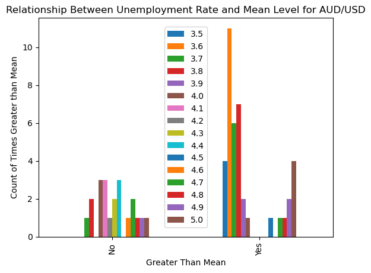

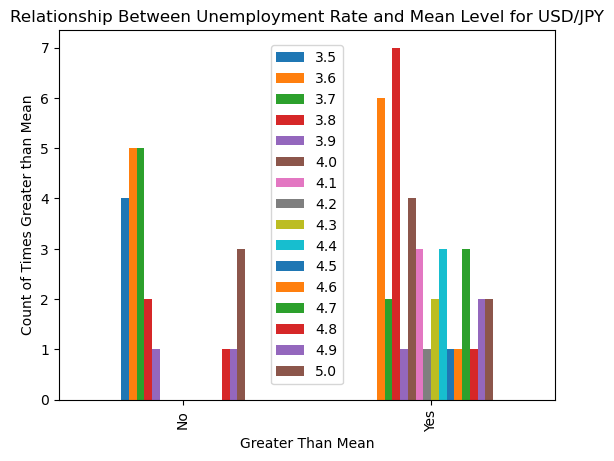

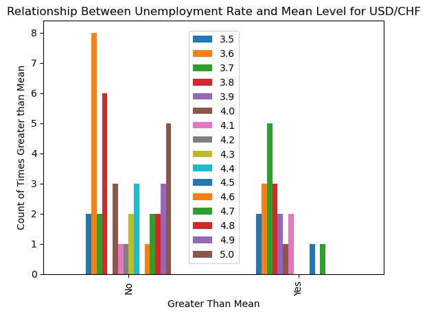

```python
# Finds the p value for each pair and plots the relationship between unemployment and mean level
for i in pairs:
    # Limiting for more common sample size
    temp_df = temp_df[temp_df['Unemployment Rate'] <= 5]

    # Find important columns
    a = temp_df[f'Greater Than Mean: {i}']
    b = temp_df['Unemployment Rate']

    # Creation of the contingency table
    table = pd.crosstab(a, b, rownames=[''], colnames=['Unemployment Rate'])

    # Plot the relationship between the two columns
    table.plot(kind='bar')
    plt.title(f'Relationship Between Unemployment Rate and Mean Level for {i}')
    plt.xlabel('Greater Than Mean')
    plt.ylabel('Count of Times Greater than Mean')
    plt.legend(loc='center')

    # Extract the p-value from the contingency table and print it out
    print(f'P-Value for {i} = {scipy.stats.chi2_contingency(table).pvalue}')
```

As you can see from the p values for USD/JPY and USD/CHF we saw p values greater than our level of significance and for the other currencies we saw p values less than our level of significance. Therefore in the case of the p values less than our level of significance we will reject our Null hypothesis and understand that unemployment rate does have an effect on our currency rate and we can say the opposite and accept our null hypothesis in the case of USD/CHF and USD/JPY as they had a p value greater than our significance level stated above.

## Part 5: Machine Learning

Now we want to make a model that creates a prediction for what the price of a forex pair should be given a certain unemployment rate. With this information if the price that is returned from the model turns out to be. So if we were to compare the predicted price to the current price we would be able to potentially make a profit with the information given to us. Because this is a continuous variable we are searching for that we are basing the theoretical price based off of we are going to use a regression model and search for a line of best fit.

**Task 5.1**: To do this we want to create a dataframe with our unemployment rates and our closing rates for all of our forex pairs. In addition to this remove outliers that arose to COVID.

```python
# This is because we only have unemployment data released on the 1st of every month so we have to filter for it
df = df[df["Date"].dt.day == 1]
df = pd.merge(df, unemployment_df)
df = df[df["Unemployment Rate"] <= 6.0]
```

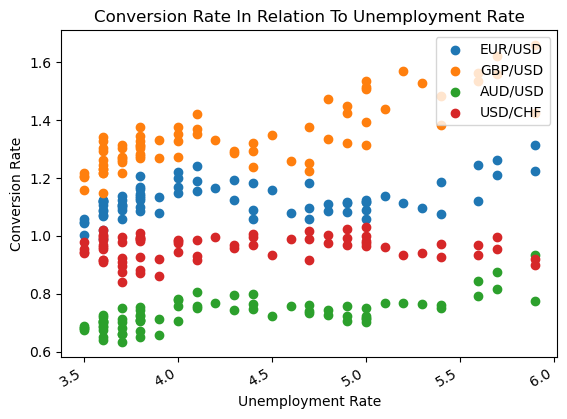

```python
# We want to plot the relationship between unemployment rate and the different pairs to get a good feeling of the data set in scatter plots
plt.scatter(df['Unemployment Rate'], df['EUR/USD'], label = "EUR/USD")
plt.scatter(df['Unemployment Rate'], df['GBP/USD'], label = "GBP/USD")
plt.scatter(df['Unemployment Rate'], df['AUD/USD'], label = "AUD/USD")
plt.scatter(df['Unemployment Rate'], df['USD/CHF'], label = "USD/CHF")

# I decided to ignore USD/JPY for the moment as because it trades for 150 currently which makes the graph unreadable

# Settings for the plot
plt.xlabel('Unemployment Rate')
plt.ylabel('Conversion Rate')
plt.title('Conversion Rate In Relation To Unemployment Rate')
plt.gcf().autofmt_xdate()
plt.legend(loc="upper right")
plt.show()
```

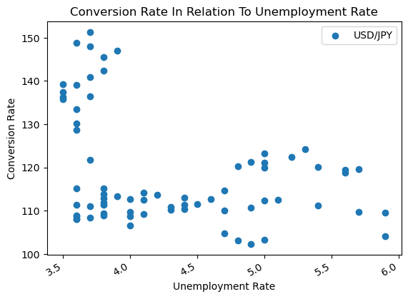

```python
# Ignored USD/JPY in the plot itself as it made the graph to spaced out as USD/JPY averages around the 100s
# Plotted USD/JPY by itself for mroe identification
plt.scatter(df['Unemployment Rate'], df['USD/JPY'], label = "USD/JPY")

# Settings for the plot
plt.xlabel('Unemployment Rate')
plt.ylabel('Conversion Rate')
plt.title('Conversion Rate In Relation To Unemployment Rate')
plt.gcf().autofmt_xdate()
plt.legend(loc="upper right")
plt.show()
```

USD/JPY however doesn't seem to follow a particular linear relation so we might have to tweak the degree it uses a little based off the differences in comparision with the other forex pairs

**Task 5.2**: For this we want to implement a regression model for our seemingly linear dataset to predict conversion rates based off unemployment in the United States.

```python
# Function to get the error rate for the model we create for a specific pair with the ability to plot it as well
def get_error_rates(pair, plot=True):
    # We first want to split the different datasets into train and test
    X_linear, Y_linear = df["Unemployment Rate"], df[pair]
    X_linear_train, X_linear_test, Y_linear_train, Y_linear_test = train_test_split(X_linear, Y_linear)

    # We do this to turn the series that we obtain into a dataframe
    X_linear_train = X_linear_train.to_frame()
    X_linear_test = X_linear_test.to_frame()

    # We fit the model to be able to work under polynomial features so that we can have a different degree that more aptly fits what we are looking for
    polyFeatures = PolynomialFeatures(degree=5, include_bias=False)
    xPolyTrain = polyFeatures.fit_transform(X_linear_train)
    xPolyTest = polyFeatures.fit_transform(X_linear_test)

    polyModelTrain = LinearRegression()
    polyModelTrain.fit(xPolyTrain, Y_linear_train)

    # This is the prediction that we get when testing the feature values in regard to the model that we created earlier
    Y_linear_test_pred = polyModelTrain.predict(polyFeatures.fit_transform(X_linear_test.values))

    # Calculate MSE and R^2
    mse_linear_test = mean_squared_error(Y_linear_test, Y_linear_test_pred)
    r2_linear_test = r2_score(Y_linear_test, Y_linear_test_pred)

    # This is simply in regards to whether or not you want to plot the regression line and the scatter plot with the train and test data highlighted
    if plot :
        xDeltaTrain = np.linspace(X_linear_train.min(), X_linear_train.max(), 1000)
        yDeltaTrain = polyModelTrain.predict(polyFeatures.fit_transform(xDeltaTrain.reshape(-1, 1)))

        # Graph the quadratic regression
        train_data = plt.scatter(X_linear_train, Y_linear_train, color='cyan')
        test_data = plt.scatter(X_linear_test, Y_linear_test, color='red')
        train_data.set_label('Train Data')
        test_data.set_label('Test Data')


        plt.plot(xDeltaTrain, yDeltaTrain, color='orange', linewidth=2, label='Regression Line')
        plt.legend(loc="upper right")
        plt.xlabel('Unemployment Rate', fontsize=10)
        plt.ylabel('Conversion Rate', fontsize=10)
        plt.title(f'Relation of Unemployment Rate and Conversion Rate for {pair}', fontsize=10)

        plt.show()

    # Return the MSE and R2 score in terms of a tuple
    return mse_linear_test, r2_linear_test
```

**Task 5.3**: Now that we have a way to plot and analyze our regression model I think it would be interesting to figure out the average MSE score and R2 score given different splits and their corresponding line of best fit in addition to how that relates for every individual pair.

```python
iterations = 100
average_mse = 0
average_r2 = 0

# We want to find the average MSE and R2 score for each pair and we do this by iteratively getting the current MSE and R2 and then dividing it by the number of iterations chosen.
for i in pairs:
    for j in range(iterations):
        curr_mse, curr_r2 = get_error_rates(i, plot=False)

        average_mse += curr_mse
        average_r2 += curr_r2

    print(f"Information Regarding {i}\n-----------------------------\nThe average MSE is {average_mse/iterations}\nThe average R2 score is {average_r2/iterations}\n")
    average_mse, average_r2 = 0, 0
```

```
Information Regarding GBP/USD
-----------------------------
The average MSE is 0.0046229958956269445
The average R2 score is 0.5836185076523013

Information Regarding EUR/USD
-----------------------------
The average MSE is 0.0018631956472588962
The average R2 score is 0.3258640449192415

Information Regarding AUD/USD
-----------------------------
The average MSE is 0.0013903940633177086
The average R2 score is 0.41560903127848997

Information Regarding USD/JPY
-----------------------------
The average MSE is 131.1573442645359
The average R2 score is 0.08321896892888642

Information Regarding USD/CHF
-----------------------------
The average MSE is 0.0018285870292446447
The average R2 score is -0.1572883373766469
```

Looking at the error rates and the R2 score I believe it is clear to see that our model is not accurate enough to work based solely off of the unemployment rate

## Part 6: Visualization

As our main question was trying to predict how unemployment rate would relate to conversion rate between currencies I decided to show the model we created and the regression line that arose from it.

As you can see how our regression line follows the training data and creates a line of best fit from the data that was given to it. After that we test our predictions with the test data which is in red however one can often see the problem. They are so far out sometimes which arises in not the best estimates leading to higher errors. The intersting thing is that this can be translated to higher conversion rates as in the case of USD/JPY. I also chose the degree 5 as it warranted the highest possible r2 score on average which enough iterations.

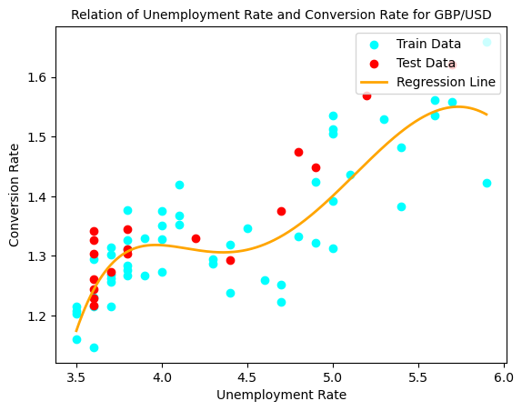

```
Information Regarding GBP/USD
-----------------------------
The MSE is 0.0035444671234330857
The R2 score 0.702541002750887
```

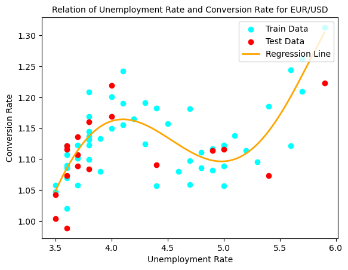

```
Information Regarding EUR/USD
-----------------------------
The MSE is 0.00205594147734057
The R2 score 0.44147806372461085
```

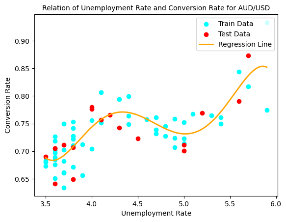

```
Information Regarding AUD/USD
-----------------------------
The MSE is 0.0008801397455916797
The R2 score 0.6953667652484221
```

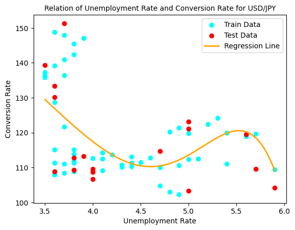

```
Information Regarding USD/JPY
-----------------------------
The MSE is 117.19229316794274
The R2 score 0.2883402303162542
```

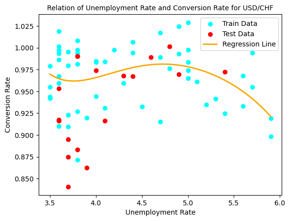

```
Information Regarding USD/CHF
-----------------------------
The MSE is 0.0029581351445620886
The R2 score -0.2394778469677885
```

```python
# Plot the regression lines for each pair and highlight test and train data with the MSE and R2 score for each pair as well
for i in pairs:
    curr_mse, curr_r2 = get_error_rates(i, plot=True)
    print(f"Information Regarding {i}\n-----------------------------\nThe MSE is {curr_mse}\nThe R2 score {curr_r2}\n")
```

## Part 7: Insights and Conclusions

I hope that you as a reader was able to not only learn more about forex but how important it is in our daily lives. How in some cases unemployment can be a good indicator on what a conversion rate can be and the parts that it has its own flaws. As we can see from our predictions in most cases on average we are not able to reach a suitable percentage to have meaningingful insight that is gained. It should be stated that the correlation actually has to be really high especially in the case with forex pairs. When they are assessed they are often to the 4th decimal place, for example 1.4000. And it should be noted that a movement from 1.4000 to 1.4001 would actually have to some importance as forex pairs are heavily leveraged in some cases meaning that such a simple move could cost millions of losses depending on the position. So with such a low r2 score we have to tread very carefully. In addition to this we can see from the data that unemployment rate doesn't give us enough information. For example lets look at USD/CHF, we have the same conversion when the unemployment rate was 3.5 as it was when it was 5.0. There also seems to be a vertical line almost at the 3.5 unemployment rate that well represents the data to so our regression line isn't able to account for the variance. In this case we even received a negative R2 score in one cycle which is honestly unnaceptable in the context of making a profit. It was interesting confirming that one feature certainly isn't enough and I would definitely have fun maybe making this more dimensional in the future and learn more. I plan to study more about the intersection between finance and computer science and hope to take you all on the ride with me.